# K-Means Clustering

# **Customer Segmentantion**

You were just hired as a data scientist for one of the largest retailer companies: MarketCo. MarketCo offers its customers store credit cards. MarketCo has collected transactions of these credit cards. You are asked by your boss, Mr. Johnson, to develop a customer segmentation to define marketing strategy. You are given a historical dataset summarizing the usage behavior of about 9,000 active credit card holders during the last 6 months. You are asked to perform cluster analysis of this dataset.

**Data Source:** Kaggle at https://www.kaggle.com/arjunbhasin2013/ccdata/home

## **Data Dictionary**

This dataset contains the following columns:

| **Variable Name** | **Data Type** | **Description** | **Constraints/Rules** |
| --- | --- | --- | --- |
| `CUST_ID` | Integer | Row identifier or index | Unique, Non-null |
| `BALANCE` | Float | Current balance on the card | ≥ 0, Non-null |
| `BALANCE_FREQUENCY` | Float | How frequently the balance is updated | Range: [0.0, 1.0], Non-null |
| `PURCHASES` | Float | Total amount of purchases made | ≥ 0, Non-null |
| `ONEOFF_PURCHASES` | Float | Purchases made in a single transaction | ≥ 0, ≤ `PURCHASES`, Non-null |
| `INSTALLMENTS_PURCHASES` | Float | Purchases made in installments | ≥ 0, ≤ `PURCHASES`, Non-null |
| `CASH_ADVANCE` | Float | Cash advances taken | ≥ 0, Non-null |
| `PURCHASES_FREQUENCY` | Float | Frequency of making purchases | Range: [0.0, 1.0], Non-null |
| `ONEOFF_PURCHASES_FREQUENCY` | Float | Frequency of one-off purchases | Range: [0.0, 1.0], Non-null |
| `PURCHASES_INSTALLMENTS_FREQUENCY` | Float | Frequency of purchases in installments | Range: [0.0, 1.0], Non-null |
| `CASH_ADVANCE_FREQUENCY` | Float | Frequency of cash advances | Range: [0.0, 1.0], Non-null |
| `CASH_ADVANCE_TRX` | Integer | Number of cash advance transactions | ≥ 0, Non-null |
| `PURCHASES_TRX` | Integer | Number of purchase transactions | ≥ 0, Non-null |
| `CREDIT_LIMIT` | Integer | Credit limit assigned to the card | ≥ 0, Non-null |
| `PAYMENTS` | Float | Total amount of payments made | ≥ 0, Non-null |
| `MINIMUM_PAYMENTS` | Float | Minimum payments made | ≥ 0, Non-null |
| `PRC_FULL_PAYMENT` | Float | Proportion of months with full payment of balance | Range: [0.0, 1.0], Non-null |
| `TENURE` | Integer | Number of months the customer has been active (usually 12) | Integer ≥ 0, Non-null, typically constant (12) across records |

## **Question 1**

**Load the dataset CreditCards.csv into memory.**

Read the dataset into memory

```r
CreditCards.df <- read.csv("data/CreditCards.csv")
```

Display the dimensions of the data frame (number of rows and columns)

```r
dim(CreditCards.df)
```

```
## [1] 8950   18
```

Display the column names of the data frame

```r
colnames(CreditCards.df)
```

```
##  [1] "X"                                "BALANCE"
##  [3] "BALANCE_FREQUENCY"                "PURCHASES"
##  [5] "ONEOFF_PURCHASES"                 "INSTALLMENTS_PURCHASES"
##  [7] "CASH_ADVANCE"                     "PURCHASES_FREQUENCY"
##  [9] "ONEOFF_PURCHASES_FREQUENCY"       "PURCHASES_INSTALLMENTS_FREQUENCY"
## [11] "CASH_ADVANCE_FREQUENCY"           "CASH_ADVANCE_TRX"
## [13] "PURCHASES_TRX"                    "CREDIT_LIMIT"
## [15] "PAYMENTS"                         "MINIMUM_PAYMENTS"
## [17] "PRC_FULL_PAYMENT"                 "TENURE"
```

## **Question 2**

**Perform the k-means cluster analysis**

### **Section A**

**Remove the first column: CUST_ID since it doesn’t provide any info for cluster.**

Remove the first column

```r
CreditCards.df <- CreditCards.df[,-1]
```

Display the dimensions of the data frame (number of rows and columns)

```r
dim(CreditCards.df)
```

```
## [1] 8950   17
```

Display the column names of the data frame

```r
colnames(CreditCards.df)
```

```
##  [1] "BALANCE"                          "BALANCE_FREQUENCY"
##  [3] "PURCHASES"                        "ONEOFF_PURCHASES"
##  [5] "INSTALLMENTS_PURCHASES"           "CASH_ADVANCE"
##  [7] "PURCHASES_FREQUENCY"              "ONEOFF_PURCHASES_FREQUENCY"
##  [9] "PURCHASES_INSTALLMENTS_FREQUENCY" "CASH_ADVANCE_FREQUENCY"
## [11] "CASH_ADVANCE_TRX"                 "PURCHASES_TRX"
## [13] "CREDIT_LIMIT"                     "PAYMENTS"
## [15] "MINIMUM_PAYMENTS"                 "PRC_FULL_PAYMENT"
## [17] "TENURE"
```

### **Section B**

**Determine the optimal number of clusters. Justify your answer. It may take longer running time since it uses a large dataset.**

Set seed for reproducibility

```r
set.seed(123)
```

Scale the data for clustering

```r
scaled_data <- scale(CreditCards.df)
```

Determine the optimal number of clusters using “gap_stat” Method

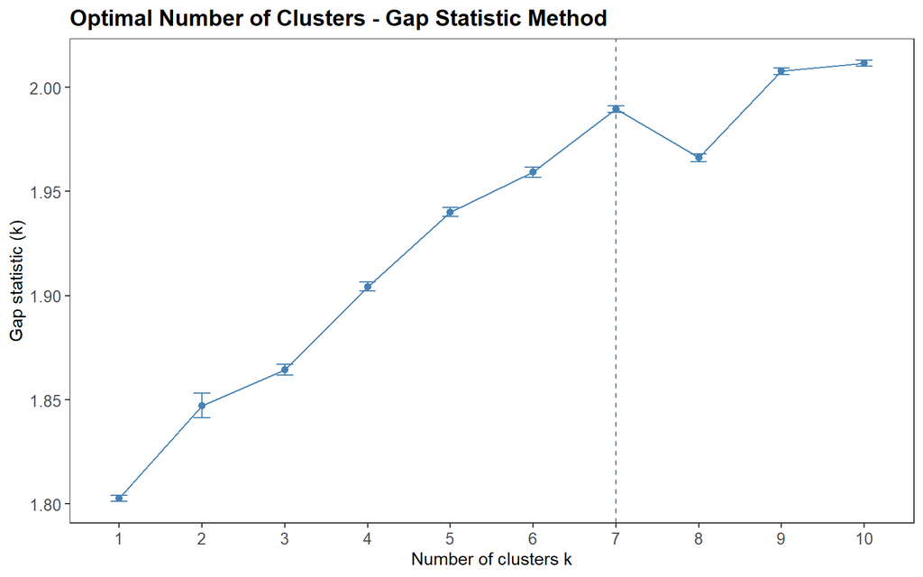

```r
fviz_nbclust(scaled_data, kmeans, method = "gap_stat") +
  ggtitle("Optimal Number of Clusters - Gap Statistic Method") +
  theme_test() +
  theme(
    plot.title = element_text(size = 14, face = "bold"),
    axis.text = element_text(size = 10)
  )
```

Determine the optimal number of clusters using “Silhouette” Method

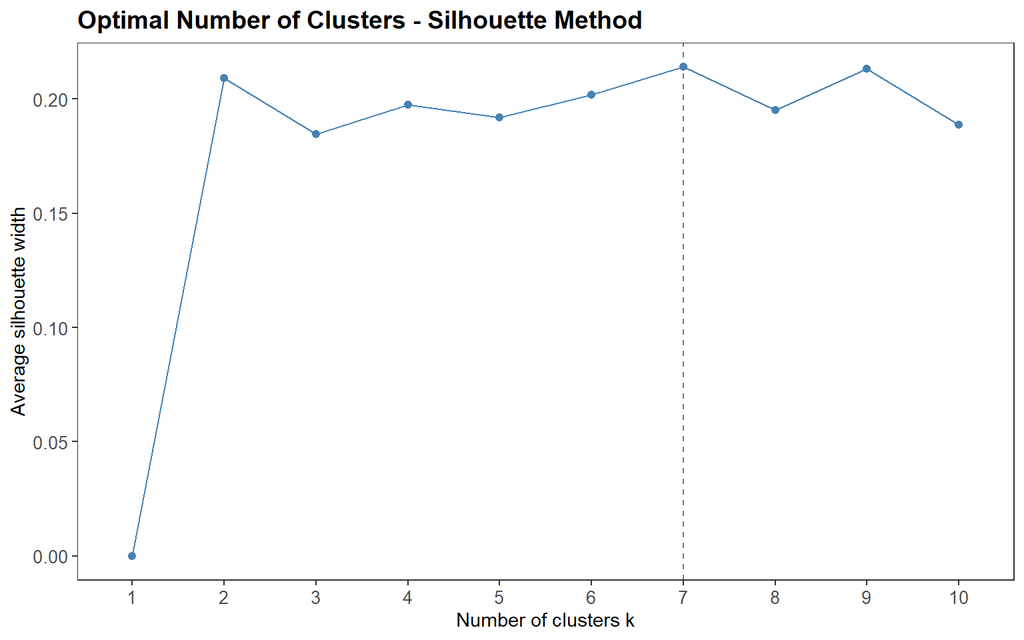

```r
fviz_nbclust(scaled_data, kmeans, method = "silhouette") +
  ggtitle("Optimal Number of Clusters - Silhouette Method") +
  theme_test() +
  theme(
    plot.title = element_text(size = 14, face = "bold"),
    axis.text = element_text(size = 10)
  )
```

The Silhouette Method has recommended 7 clusters as the optimal number for K-means clustering on the scaled_data. This value ensures a good balance between cluster cohesion (how close points in the same cluster are) and separation (how distinct each cluster is from the others).

Set observed optimal number

```r
optimal_k <- 7
```

### **Section C**

**Perform k-means clustering using the optimal number of clusters.**

Perform k-means clustering

```r
kmeans_result <- kmeans(scaled_data, centers = optimal_k, nstart = 25)
```

Display the statistical summary of the kmeans

```r
summary(kmeans_result)
```

```
##              Length Class  Mode
## cluster      8950   -none- numeric
## centers       119   -none- numeric
## totss           1   -none- numeric
## withinss        7   -none- numeric
## tot.withinss    1   -none- numeric
## betweenss       1   -none- numeric
## size            7   -none- numeric
## iter            1   -none- numeric
## ifault          1   -none- numeric
```

### **Section D**

**Visualize the clusters in different colors.**

Add the cluster assignment to the original data

```r
CreditCards.df$Cluster <- as.factor(kmeans_result$cluster)
```

Visualize the clusters

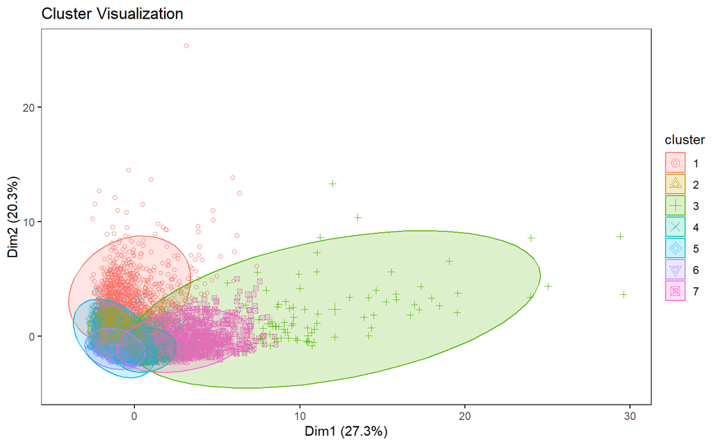

```r
fviz_cluster(
  kmeans_result,
  data = scaled_data,
  geom = "point",
  ellipse.type = "norm",
  ggtheme = theme_test(),
  main = "Cluster Visualization"
)
```